# EE0848 Machine Learning for SP

Week 7: Boosting

Basri Erdogan

## Last Week

Decision Trees and Ensemble Methods

- Decision trees: recursive partitioning, information gain, pruning
- Ensemble idea: combine multiple models for better performance
- **Bagging** and **Random Forests**: parallel ensembles that reduce variance

## Today

- From Bagging to Boosting: a different ensemble strategy
- **AdaBoost**: the adaptive boosting algorithm
- **Gradient Boosting**: a general framework
- **XGBoost, LightGBM, CatBoost**: modern implementations
- Practical considerations: tuning, early stopping, interpretability

# The Boosting Idea

## Can Weak Learners Become Strong?

A **weak learner** is a classifier that does only slightly better than random guessing.

A **strong learner** achieves arbitrarily high accuracy.

**Note**

**Schapire (1990):** Proved that any weak learner can be “boosted” into a strong learner by combining many weak learners sequentially.

This was a breakthrough in computational learning theory — it means we don’t need complex models, just **many simple ones combined cleverly**.

## Weak vs. Strong Learners

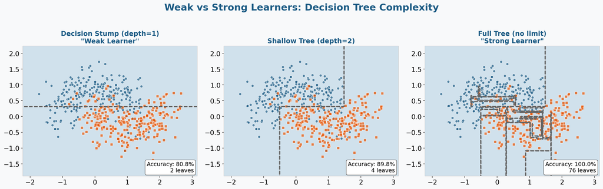

A **decision stump** (depth-1 tree) is the classic weak learner — it can only split on a single feature.

## Many Weak Learners = One Strong Learner

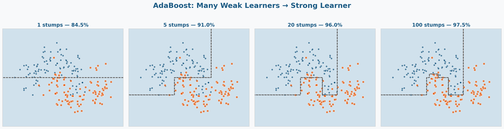

Each stump alone is poor, but their **weighted combination** captures complex boundaries.

## Bagging vs. Boosting

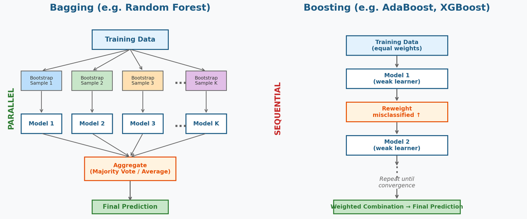

## Bagging vs. Boosting: Key Differences

|  | **Bagging** | **Boosting** |
| --- | --- | --- |
| **Training** | Parallel (independent models) | Sequential (each depends on previous) |
| **Sampling** | Bootstrap samples | Reweight samples based on errors |
| **Focus** | All samples treated equally | Misclassified samples get more attention |
| **Reduces** | Primarily **variance** | Primarily **bias** (and variance) |
| **Risk** | Low overfitting risk | Can overfit if not regularized |
| **Example** | Random Forest | AdaBoost, XGBoost |

# AdaBoost

## AdaBoost: The Intuition

**Ada**ptive **Boost**ing (Freund & Schapire, 1997)

The core idea is beautifully simple:

1. Start with equal weights on all training samples
2. Train a weak learner
3. **Increase weights** on misclassified samples
4. **Decrease weights** on correctly classified samples
5. Train the next weak learner on the reweighted data
6. Repeat — each new learner focuses on the **mistakes** of the previous ones

The final model is a **weighted vote** of all weak learners.

## AdaBoost Algorithm

$N$ = number of training samples, $T$ = number of boosting rounds, $w_i$ = sample weight, $h_t(x)$ = weak learner at round $t$

**Initialize:** $w_i^{(1)} = \frac{1}{N}$ for all $i = 1, \ldots, N$

**For** $t = 1, 2, \ldots, T$:

1. Train weak learner $h_t(x)$ using weights $\mathbf{w}^{(t)}$
2. Compute weighted error: $\;\varepsilon_t = \frac{\sum_{i} w_i^{(t)} \cdot \mathbb{1}[h_t(x_i) \neq y_i]}{\sum_{i} w_i^{(t)}}$
3. Compute learner weight: $\;\alpha_t = \frac{1}{2} \ln\!\left(\frac{1 - \varepsilon_t}{\varepsilon_t}\right)$
4. Update weights: $\;w_i^{(t+1)} = w_i^{(t)} \cdot e^{-\alpha_t \, y_i \, h_t(x_i)}$
5. Normalize: $\;w_i^{(t+1)} \leftarrow \frac{w_i^{(t+1)}}{\sum_j w_j^{(t+1)}}$

**Final prediction:** $\;H(x) = \text{sign}\!\left(\sum_{t=1}^{T} \alpha_t \, h_t(x)\right)$

**Key insight:** Better classifiers ($\varepsilon_t$ small) get **higher** $\alpha_t$

- $\varepsilon_t = 0.5$ (random guessing) → $\alpha_t = 0$ (ignored)
- $\varepsilon_t < 0.5$ (better than random) → $\alpha_t > 0$
- $\varepsilon_t \to 0$ (perfect) → $\alpha_t \to \infty$

**Step 4 insight:** Since $y_i, h_t(x_i) \in \{-1, +1\}$:

- Correct → $y_i \cdot h_t = +1$ → exponent is $-\alpha_t$ → weight **shrinks**
- Wrong → $y_i \cdot h_t = -1$ → exponent is $+\alpha_t$ → weight **grows**

## Understanding $\alpha_t$: The Learner Weight

The formula $\alpha_t = \frac{1}{2} \ln\!\left(\frac{1 - \varepsilon_t}{\varepsilon_t}\right)$ maps error rate to learner importance:

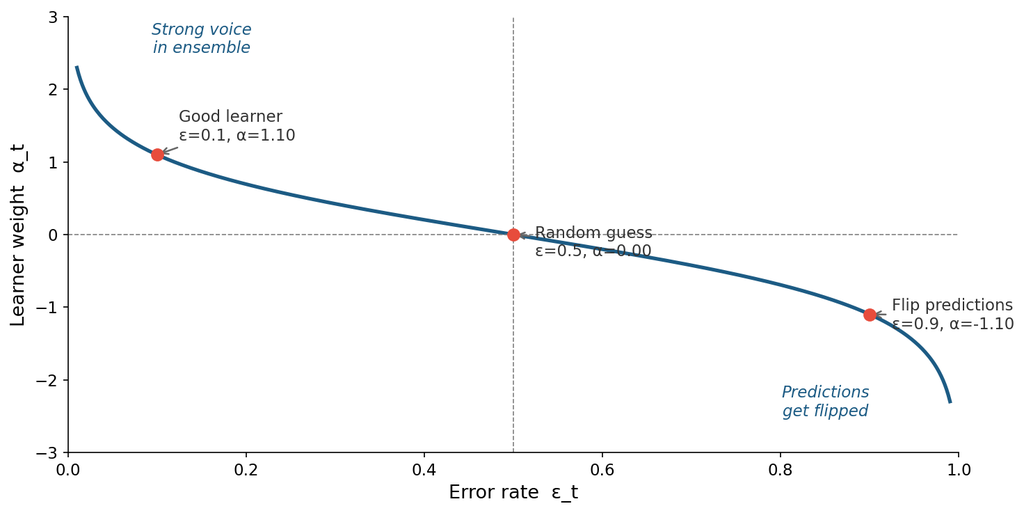

$\alpha_t$ is the **log-odds** of correctness — even slightly-better-than-random learners ($\varepsilon < 0.5$) contribute meaningfully, while worse-than-random learners get their predictions **flipped**.

## AdaBoost: Weight Evolution in Action

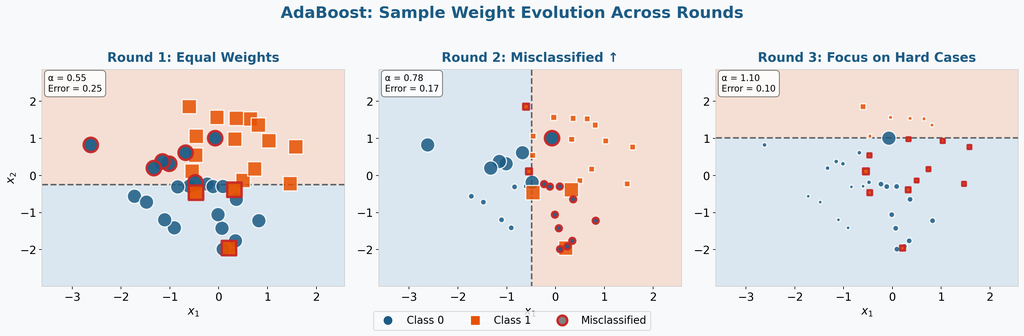

Point **size** = sample weight. Red borders = misclassified. Each round, misclassified points grow larger, forcing the next stump to focus on them.

## AdaBoost → Gradient Boosting: The Connection

AdaBoost’s reweighting and $\alpha_t$ formulas aren’t arbitrary — they are exactly what you get when you minimize **exponential loss** one tree at a time:

$$L = \sum_{i=1}^{N} e^{-y_i \, F(x_i)}$$

This means AdaBoost is secretly doing **gradient descent on a loss function**.

But exponential loss is just one choice. What if we want to use a different loss (log-loss, MSE, …)?

→ This is exactly what **Gradient Boosting** generalizes: the same idea, but with **any differentiable loss function**.

## AdaBoost: Code Example

```python
from sklearn.ensemble import AdaBoostClassifier
from sklearn.tree import DecisionTreeClassifier
from sklearn.datasets import make_moons
from sklearn.model_selection import train_test_split
from sklearn.metrics import accuracy_score

X, y = make_moons(n_samples=500, noise=0.3, random_state=42)
X_train, X_test, y_train, y_test = train_test_split(X, y, test_size=0.3, random_state=42)

# AdaBoost with decision stumps (depth=1)
ada = AdaBoostClassifier(
    estimator=DecisionTreeClassifier(max_depth=1),
    n_estimators=100,
    learning_rate=0.5,           # shrinks each α_t — lower = more trees needed, less overfitting
    random_state=42
)
ada.fit(X_train, y_train)
print(f"AdaBoost Accuracy: {accuracy_score(y_test, ada.predict(X_test)):.3f}")
```

```
AdaBoost Accuracy: 0.953
```

# Gradient Boosting

## From AdaBoost to Gradient Boosting

AdaBoost minimizes **exponential loss** — but what if we want a different loss?

**Gradient Boosting** (Friedman, 2001) generalizes the boosting idea:

- Works with **any differentiable loss function**
- Instead of reweighting samples, it fits each new tree to the **negative gradient** of the loss (the *pseudo-residuals*)
- For squared error loss: pseudo-residuals = actual residuals

This makes it applicable to:

- **Regression** (MSE, MAE, Huber loss)
- **Classification** (log-loss, exponential loss)

## Gradient Boosting: The Key Idea

We want to build an **additive model**:

$$F(x) = \sum_{t=1}^{T} \eta \cdot h_t(x)$$

At each step, instead of fitting $h_t$ to the original targets, we fit it to the **negative gradient** of the loss:

$$r_i^{(t)} = -\frac{\partial L(y_i, F(x_i))}{\partial F(x_i)} \bigg|_{F = F_{t-1}}$$

**MSE loss:** $L = \frac{1}{2}(y - F(x))^2$

$$r_i^{(t)} = y_i - F_{t-1}(x_i)$$

These are simply the **residuals** — each tree fits what the current model gets wrong.

**Log-loss:** $L = -[y \log p + (1-y) \log(1-p)]$

where $p = \sigma(F(x))$

$$r_i^{(t)} = y_i - p_i$$

The pseudo-residual is the gap between the true label and the predicted **probability**.

## Gradient Boosting: Residual Fitting Visualized

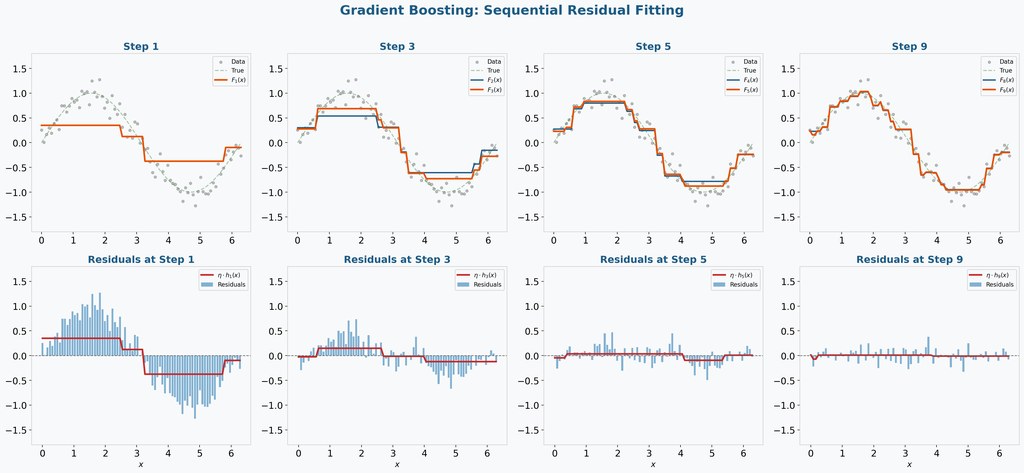

**Top row:** The model progressively approaches the true function. **Bottom row:** Each tree fits the remaining residuals, which shrink over iterations.

## Gradient Boosting: Regression vs. Classification

All trees in gradient boosting are **regression trees** — even for classification. The difference is what happens around them.

**Regression (MSE loss)**

1. $F(x)$ directly predicts the target value
2. Pseudo-residual: $r_i = y_i - F(x_i)$
3. Fit tree to residuals, update $F$
4. **Output:** $\hat{y} = F(x)$

$h_t(x) \;\xrightarrow{\text{sum}}\; F(x) \;\longrightarrow\; \hat{y}$

**Classification (log-loss)**

1. $F(x)$ outputs **log-odds**, not probabilities
2. Convert to probability: $p_i = \sigma(F(x_i))$
3. Pseudo-residual: $r_i = y_i - p_i$
4. Fit tree to residuals, update $F$ (in log-odds space)
5. **Output:** $\hat{y} = \sigma(F(x))$

$h_t(x) \;\xrightarrow{\text{sum}}\; F(x) \;\xrightarrow{\sigma}\; p \;\longrightarrow\; \hat{y}$

The trees always predict **continuous corrections** — the loss function and the link function ($\sigma$ for classification) determine how those corrections translate into final predictions.

## Gradient Boosting Algorithm

**Initialize:** $F_0(x) = \arg\min_c \sum_{i=1}^N L(y_i, c)$

**For** $t = 1, 2, \ldots, T$:

1. Compute pseudo-residuals for each sample:
   $$r_i^{(t)} = -\left[\frac{\partial L(y_i, F(x_i))}{\partial F(x_i)}\right]_{F = F_{t-1}}$$
2. Fit a regression tree $h_t$ to the pseudo-residuals $\{(x_i, r_i^{(t)})\}$
3. Update the model with a **learning rate** (shrinkage):
   $$F_t(x) = F_{t-1}(x) + \eta \cdot h_t(x)$$

**Output:** $F_T(x) = F_0(x) + \eta \sum_{t=1}^{T} h_t(x)$

## The Role of the Learning Rate $\eta$

The learning rate (shrinkage) controls how much each tree contributes:

$$F_t(x) = F_{t-1}(x) + \underbrace{\eta}_{\text{shrinkage}} \cdot h_t(x)$$

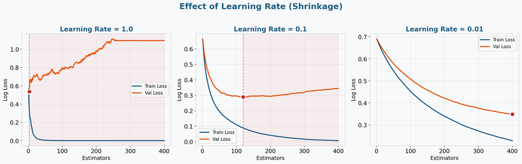

**$\eta = 1.0$:** Learns fast but validation loss **increases** — severe overfitting. **$\eta = 0.1$:** Smooth convergence, good generalization. **$\eta = 0.01$:** Both curves still improving — needs more trees.

## Early Stopping: Knowing When to Stop

More trees don’t always mean better performance — at some point, we start **memorizing noise**.

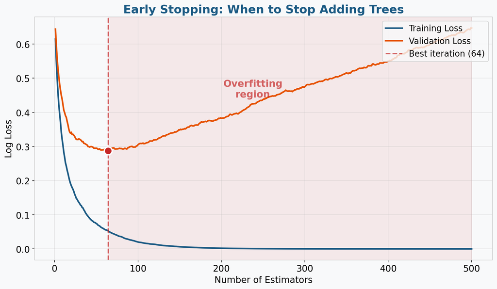

**Early stopping** monitors validation loss and stops adding trees when it starts to increase.

## Gradient Boosting: Key Hyperparameters

| Parameter | Effect | Typical Range |
| --- | --- | --- |
| `n_estimators` | Number of trees (boosting rounds) | 100 – 1000+ |
| `learning_rate` | Shrinkage per step — lower = more trees needed | 0.01 – 0.3 |
| `max_depth` | Depth of individual trees | 3 – 8 |
| `subsample` | Fraction of samples per tree (stochastic GB) | 0.5 – 1.0 |
| `min_samples_leaf` | Minimum samples in leaf node | 5 – 50 |

`learning_rate` and `n_estimators` are coupled — lower learning rate needs more estimators. Use early stopping to find the right number.

## Gradient Boosting: Code Example

```python
from sklearn.ensemble import GradientBoostingClassifier

gbc = GradientBoostingClassifier(
    n_estimators=200,
    learning_rate=0.1,
    max_depth=3,
    subsample=0.8,           # stochastic gradient boosting
    random_state=42
)
gbc.fit(X_train, y_train)
print(f"Gradient Boosting Accuracy: {accuracy_score(y_test, gbc.predict(X_test)):.3f}")
```

```
Gradient Boosting Accuracy: 0.960
```

```python
# With early stopping
gbc_es = GradientBoostingClassifier(
    n_estimators=500,
    learning_rate=0.05,
    max_depth=3,
    validation_fraction=0.2,
    n_iter_no_change=20,     # stop if no improvement for 20 rounds
    random_state=42
)
gbc_es.fit(X_train, y_train)
print(f"Stopped at {gbc_es.n_estimators_} trees")
```

[output not shown]

# Modern Boosting Libraries

## The Big Three: XGBoost, LightGBM, CatBoost

All three are **optimized implementations** of gradient boosting with additional innovations:

|  | **XGBoost** | **LightGBM** | **CatBoost** |
| --- | --- | --- | --- |
| **Developer** | Chen & Guestrin (2016) | Microsoft (2017) | Yandex (2018) |
| **Categorical** | Needs encoding | Built-in | **Best** built-in |
| **Missing values** | Built-in handling | Built-in handling | Built-in handling |
| **Regularization** | L1 + L2 on leaf values | L1 + L2 on leaf values | L1 + L2 + ordered boosting |
| **Speed** | Fast | **Fastest** | Moderate |
| **GPU support** | Yes | Yes | Yes |

## XGBoost: e**X**treme **G**radient **Boost**ing

XGBoost adds **regularization** directly into the objective:

$$\mathcal{L} = \underbrace{\sum_{i=1}^{N} L(y_i, \hat{y}_i)}_{\text{training loss}} + \underbrace{\sum_{t=1}^{T} \left[\gamma \, |T_t| + \frac{\lambda}{2} \sum_{j=1}^{|T_t|} w_j^2\right]}_{\text{regularization}}$$

where $|T_t|$ = number of leaves in tree $t$, and $w_j$ = leaf weight.

**Key innovations:**

- **Regularized objective** prevents overfitting
- **Approximate split finding** with histogram binning
- **Sparsity-aware** algorithm for missing values
- **Cache-aware** and parallel computation

## LightGBM & CatBoost

**LightGBM** (Microsoft, 2017)

- Uses smart sampling and feature bundling to train **10-20x faster** than XGBoost on large datasets
- Often the go-to choice when dataset size is a concern

**CatBoost** (Yandex, 2018)

- Handles **categorical features** natively — no manual one-hot encoding needed
- Uses **ordered boosting** to reduce overfitting
- Often the best choice when your data has many categorical features

## Code: XGBoost

```python
import xgboost as xgb

xgb_model = xgb.XGBClassifier(
    n_estimators=200,
    learning_rate=0.1,
    max_depth=4,
    subsample=0.8,
    colsample_bytree=0.8,   # feature subsampling (like Random Forest)
    reg_alpha=0.1,           # L1 regularization
    reg_lambda=1.0,          # L2 regularization
    random_state=42,
    eval_metric='logloss'
)
xgb_model.fit(
    X_train, y_train,
    eval_set=[(X_test, y_test)],
    verbose=False
)
print(f"XGBoost Accuracy: {accuracy_score(y_test, xgb_model.predict(X_test)):.3f}")
```

## Code: LightGBM

```python
import lightgbm as lgb

lgb_model = lgb.LGBMClassifier(
    n_estimators=200,
    learning_rate=0.1,
    max_depth=4,
    num_leaves=31,           # max leaves per tree (key LightGBM param)
    subsample=0.8,
    colsample_bytree=0.8,
    random_state=42,
    verbose=-1
)
lgb_model.fit(
    X_train, y_train,
    eval_set=[(X_test, y_test)],
)
print(f"LightGBM Accuracy: {accuracy_score(y_test, lgb_model.predict(X_test)):.3f}")
```

## Code: CatBoost

```python
from catboost import CatBoostClassifier

cat_model = CatBoostClassifier(
    iterations=200,
    learning_rate=0.1,
    depth=4,
    random_state=42,
    verbose=0
)
cat_model.fit(X_train, y_train, eval_set=(X_test, y_test))
print(f"CatBoost Accuracy: {accuracy_score(y_test, cat_model.predict(X_test)):.3f}")
```

**Note**

For datasets with **categorical features**, CatBoost often outperforms XGBoost and LightGBM with much less feature engineering.

# Practical Considerations

## Hyperparameter Tuning Strategy

A practical approach for tuning gradient boosting models:

**Step 1:** Fix `learning_rate = 0.1`, find good `n_estimators` with early stopping

**Step 2:** Tune tree parameters:

- `max_depth` (3 → 8)
- `min_samples_leaf` (or `min_child_weight`)

**Step 3:** Tune stochastic parameters:

- `subsample` (0.5 → 1.0)
- `colsample_bytree` (0.5 → 1.0)

**Step 4:** Tune regularization:

- `reg_alpha` (L1), `reg_lambda` (L2)

**Step 5:** Lower `learning_rate` (e.g., 0.01), increase `n_estimators`, use early stopping

```python
from sklearn.model_selection import GridSearchCV

param_grid = {
    'max_depth': [3, 5, 7],
    'subsample': [0.7, 0.8, 0.9],
    'colsample_bytree': [0.7, 0.8, 0.9],
}

grid = GridSearchCV(
    xgb.XGBClassifier(
        learning_rate=0.1,
        n_estimators=200,
        random_state=42
    ),
    param_grid, cv=5,
    scoring='accuracy'
)
grid.fit(X_train, y_train)
print(grid.best_params_)
```

## Feature Importance

Gradient boosting models provide **built-in feature importance** based on how often and how effectively each feature is used in splits.

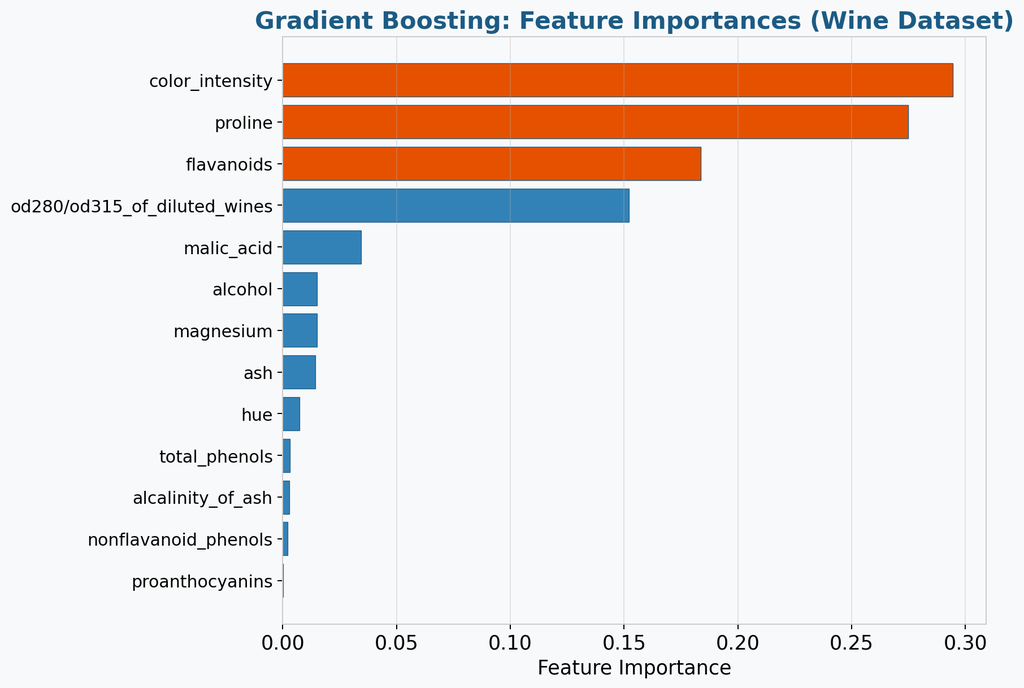

```python
# Access feature importances
importances = gbc.feature_importances_
```

## SHAP: Better Interpretability

**SHAP** (SHapley Additive exPlanations) provides theoretically grounded feature attributions:

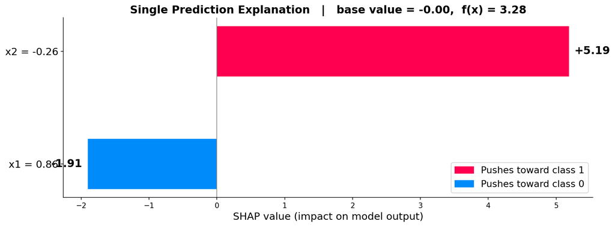

```python
import shap

explainer = shap.TreeExplainer(xgb_model)
shap_values = explainer.shap_values(X_test)

# Summary plot
shap.summary_plot(shap_values, X_test,
                  feature_names=feature_names)

# Single prediction explanation
shap.force_plot(explainer.expected_value,
                shap_values[0], X_test[0])
```

- Red: pushes prediction **higher** (toward class 1)
- Blue: pushes prediction **lower** (toward class 0)
- Shows **how much** and **in which direction** each feature contributes

## Boosting for Regression

Gradient boosting works naturally for **regression** tasks:

```python
from sklearn.ensemble import GradientBoostingRegressor

gbr = GradientBoostingRegressor(
    n_estimators=200,
    learning_rate=0.1,
    max_depth=4,
    loss='squared_error',    # also: 'absolute_error', 'huber'
    random_state=42
)
gbr.fit(X_train, y_train)
```

| Loss Function | Pseudo-residual | Robustness |
| --- | --- | --- |
| `squared_error` | $y_i - F(x_i)$ | Sensitive to outliers |
| `absolute_error` | $\text{sign}(y_i - F(x_i))$ | More robust |
| `huber` | Hybrid of the two | Good default for noisy data |

## When to Use Boosting?

**Use boosting when:**

- Tabular / structured data
- You need high predictive accuracy
- Feature interactions matter
- You have a reasonable amount of data
- Interpretability via feature importance is sufficient

**Consider alternatives when:**

- Data is very small → simpler models (logistic regression)
- Data is images/text/audio → deep learning
- Training speed is critical → Random Forest
- You need a very simple, interpretable model → single decision tree

Gradient boosting (especially XGBoost/LightGBM) is the **dominant approach** for tabular data in both industry and Kaggle competitions.

## Common Pitfalls

1. **Forgetting to scale the learning rate with n_estimators** — lower learning rate always needs more trees
2. **Not using early stopping** — without it, boosting will eventually overfit
3. **Ignoring feature engineering** — boosting is powerful, but garbage in = garbage out
4. **Using too deep trees** — unlike Random Forests, boosting trees should be **shallow** (depth 3–8). Deep trees overfit because errors compound sequentially
5. **Not shuffling time-series data properly** — boosting assumes i.i.d. samples. For time series, use time-based cross-validation

# Summary

## Week 7 Recap

**Concepts:**

- Boosting = sequential ensemble that reduces **bias**
- Weak learners + adaptive reweighting → strong learner
- **AdaBoost**: reweight misclassified samples, weighted vote
- **Gradient Boosting**: fit trees to negative gradients (residuals)
- **Learning rate** controls contribution of each tree

**Modern tools:**

- **XGBoost**: regularized objective, fast, robust
- **LightGBM**: leaf-wise growth, GOSS, fastest
- **CatBoost**: ordered boosting, great for categorical data

**Practice:**

- Use early stopping + cross-validation
- Tune learning rate, max_depth, subsample
- Feature importance + SHAP for interpretability

## Next Week

**Unsupervised Learning**

- Clustering (K-Means, DBSCAN, Hierarchical)
- Dimensionality Reduction (PCA, t-SNE)
- When there are no labels to learn from